# Midterm - Predicting Housing Prices in Philadelphia

Shuya Guan, Jiatong Su

# Introduction

This report aims to offer a detailed housing price prediction in Philadelphia, providing a prediction model to Zillow. Housing prices are influenced by multiple factors, reflecting social, environmental, and economic, among others. Regarding the hedonic model, house prices can be deconstructed by three dominant features, including physical characteristics, public service and amenities, and spatial process of prices namely that house prices cluster at the division. For example, housing prices can be explained as constituent parts such as the amount of bedrooms, the presence of a pool, and crime incidents. Therefore, the report analysis collects diverse datasets, including the Philadelphia properties and Current Assessments, census tract data, neighborhoods/districts, and shooting victims data.

This report employs geospatial analysis and machine learning to examine the housing prices in Philadelphia while utilizing Ordinary Least Square regression (OLS regression) analysis to explain housing price prediction. Moreover, accurately predicting housing prices is difficult due to the vast variables involved. Many variables from the dataset weakly demonstrate housing prices, which makes it difficult to address the accuracy of regression modeling.

To address these difficulties, two regression models use different sets of variables to examine the sale prices, then comparing those regression models determine which feature contributes significantly to the price variable. Additionally, completing various error metrics tests the goodness of fit on the training data, which provides a more reliable validation approach.

Finally, the resulting output has a certain possibility of demonstrating housing prediction in Philadelphia through the regression and accuracy metrics. By comparing two regression results, we find that neighborhood and district factors have a significant effect on the housing sale price. This reflects the location variables that are important in accurately predicting housing prices in Philadelphia.

# Data Processing

In order to make sure the modeling is efficient, processing the necessary variables is crucial thing for our regression analysis. During the data processing, utilizing `mutate()` builds the new column by specifying existed column, leading the data to be clearer and more understanding. In the following section, we focus on possible variables to minimize noise and make our regression model efficient. To confirm the regression model is reasonable, we set the baseline for some variables. First, filtering shooting data keeps only records of 2023 shooting victims. Second, creating a baseline data frame filters irrational data. For example, some rows present over 10 bedrooms, and the housing age is older than 500. Therefore, filtering the unreasonable data is significant for our analysis. Thirdly, using ‘st_join()’ combines the neighborhood and district data. Finally, Creating a buffer to sum shooting victims within a 1/8 mile buffer distance of each Philadelphia properties observation, then utilizing nn_function builds the nearest observations to each observation.

```r
train <- primary_data %>%
 mutate(Age = 2024 - year_built) %>%
  mutate(
    base = case_when(
      basements == "A" ~ "Full Finished",
      basements == "B" ~ "Full semi-Finished",
      basements == "C" ~ "Full UnFinished",
      basements == "D" ~ "Full – Unknown Finish",
      basements == "E" ~ " Partial Finished",
      basements == "F" ~ "Partial Semi-Finished ",
      TRUE ~ "NONE"
    ),
    CategoryCode = case_when(
     category_code == 1 ~ "Residential",
     category_code == 2 ~ "Hotels and Apartments",
     category_code == 3 ~ "Store with Dwelling",
     category_code == 4 ~ "Commercial",
     category_code == 5 ~ "Industrial",
     category_code == 6 ~ "Vacant Land",
     TRUE ~ "other"),
    cen_air = case_when(
         central_air %in% c("1", "Y") ~ "Y",
         TRUE~ "N"),
    Fuel = case_when(
     fuel == "a" ~ "Natural Gas",
     fuel == "b" ~ "Oil heat",
     fuel == "c" ~ "Electric (usually in excess of 150 amps)",
     fuel == "d" ~ "coal",
     fuel == "e" ~ "solar",
     fuel == "f" ~ "wood",
     fuel == "g" ~ "other",
     fuel == "h" ~ "None",
     fuel == "f" ~ "Vacant Land",
     TRUE ~ "NA"
    ),
    Heater = case_when(
         type_heater == 0 | is.na(type_heater)  ~ "N",
         TRUE~ "Y"),
    quality = case_when(
         quality_grade %in%
           c("4", "5", "6", "A", "A+", "A-", "B", "B+","B-","S","S+","X-")  ~ "Good",
         TRUE~ "Bad"),
    Garage = case_when(
         garage_type == 0 | is.na(garage_type)  ~ "N",
         TRUE~ "Y"),
    building = case_when(
         grepl("ROW",building_code_description_new, ignore.case = FALSE) ~ "Row",
         grepl("TWIN",building_code_description_new, ignore.case = FALSE) ~ "TWIN",
        TRUE~ "Other")
    )

shooting.23 <-
  shooting %>%
   filter(YEAR == 2023) %>%
    dplyr::select(geometry) %>%
    na.omit() %>%
    st_transform('ESRI:102286') %>%
    distinct()

challenge <- train %>%
  filter(toPredict == "CHALLENGE")

# filtering unreasonable data.

baseline <- train %>%
  filter(sale_price <= 3000000, Age < 500, number_of_bedrooms <= 10) %>%
  filter(toPredict != "CHALLENGE")



baseline <- st_join(baseline, dist, join = st_intersects)
baseline <- st_join(baseline, phiily_hoods, join = st_intersects)

challenge <- st_join(challenge , dist, join = st_intersects)
challenge  <- st_join(challenge, phiily_hoods, join = st_intersects)
```

```r
#buffer and Knn

baseline$shooting.Buffer <- baseline %>%
    st_buffer(600) %>%
    aggregate(mutate(shooting.23, counter = 1),., sum) %>%
    pull(counter)

challenge$shooting.Buffer <- challenge %>%
    st_buffer(600) %>%
    aggregate(mutate(shooting.23, counter = 1),., sum) %>%
    pull(counter)

nn_function <- function(measureFrom, measureTo, k) {

  # Step 0: Remove rows with NA values in measureFrom and measureTo coordinates
  measureFrom_clean <- measureFrom[complete.cases(measureFrom), ]
  measureTo_clean <- measureTo[complete.cases(measureTo), ]

  # Step 1: Use get.knnx to get a matrix of nearest neighbor distances (nn.dist)
  nn_result <- get.knnx(measureTo_clean, measureFrom_clean, k = k)

  # Step 2: Convert the nn.dist matrix to a data frame
  nn_dist_df <- as.data.frame(nn_result$nn.dist)

  # Step 3: Add a unique field for each `measureFrom` point
  nn_dist_df <- nn_dist_df %>% rownames_to_column("measureFrom")

  # Step 4: Convert from wide to long format for easy manipulation
  nn_long <- nn_dist_df %>%
    gather(key = "neighbor_rank", value = "distance", -measureFrom)

  # Step 5: Sort by the measureFrom field ascending
  nn_long <- nn_long %>% arrange(as.numeric(measureFrom))

  # Step 6: Group by each `measureFrom` point and calculate the mean distance
  nn_avg_dist <- nn_long %>%
    group_by(measureFrom) %>%
    summarize(mean_distance = mean(distance, na.rm = TRUE))

  # Step 7: Convert `measureFrom` to numeric, sort again, and return the mean distances
  nn_avg_dist <- nn_avg_dist %>%
    mutate(measureFrom = as.numeric(measureFrom)) %>%
    arrange(measureFrom) %>%
    pull(mean_distance)

  return(nn_avg_dist)
}


baseline <- baseline %>%
  mutate(
    shooting_nn1 = nn_function(st_coordinates(st_centroid(baseline)),
                             st_coordinates(st_centroid(shooting.23)), k = 1),
    shooting_nn2 = nn_function(st_coordinates(st_centroid(baseline)),
                             st_coordinates(st_centroid(shooting.23)), k = 2),
    shooting_nn3 = nn_function(st_coordinates(st_centroid(baseline)),
                             st_coordinates(st_centroid(shooting.23)), k = 3),
    shooting_nn4 = nn_function(st_coordinates(st_centroid(baseline)),
                             st_coordinates(st_centroid(shooting.23)), k = 4),
    shooting_nn5 = nn_function(st_coordinates(st_centroid(baseline)),
                             st_coordinates(st_centroid(shooting.23)), k = 5)
  )
```

# Summarize Data

In the section, we chose some variables to explain the sale_price in the regression models. We observe the correlation between the sale_price and continuous variables and visualize the value distribution of variables. The following table and plots show some explanatory variables.

## Exploratory Analysis of Correlations

```r
varibles <-
  baseline %>% st_drop_geometry() %>%
  dplyr::select(sale_price, total_area, building, quality,
                total_livable_area, number_of_bedrooms, number_of_bathrooms, cen_air, Age, DIST_NAME, starts_with("shooting_"))

stargazer(varibles, type = "text", title = "Descriptive Statistics", summary = TRUE)
```

```
##
## Descriptive Statistics
## ===================================================================
## Statistic             N       Mean      St. Dev.    Min      Max
## -------------------------------------------------------------------
## sale_price          23,740 270,671.200 221,707.000 10,100 3,000,000
## total_area          23,668  1,822.062   3,757.021    0     226,512
## total_livable_area  23,740  1,331.555    539.758     0     15,246
## number_of_bedrooms  23,740    2.579       1.224      0        9
## number_of_bathrooms 23,499    1.072       0.673      0        8
## Age                 23,740   86.451      29.544      0       274
## shooting_nn1        23,740   366.912     409.941   0.909  4,108.526
## shooting_nn2        23,740   450.715     460.932   11.020 4,162.918
## shooting_nn3        23,740   520.216     508.245   16.956 4,204.533
## shooting_nn4        23,740   585.524     552.929   19.589 4,332.835
## shooting_nn5        23,740   649.332     607.448   28.840 4,526.404
## -------------------------------------------------------------------
```

`sale_price` is plotted as function of five numeric feature, which are `age` (a feature crated from year_build), `total_area` , `number_of_bedroom`, `shooting.Buffer`, and `total_livable_area`.

In the following variables, `total_livable_area` is the largest positive association with `sale_price`, `age` is the fewest negative relationship with `sale_price`.

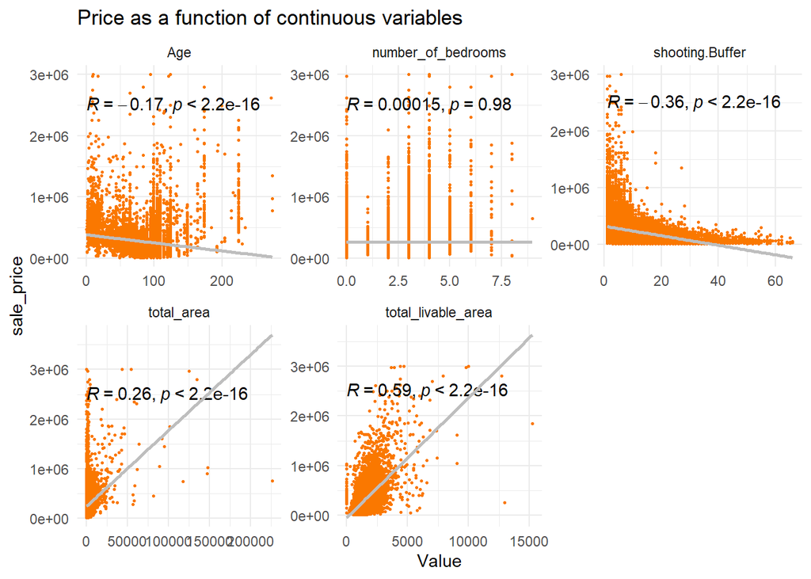

```r
baseline %>%
  st_drop_geometry() %>%
  dplyr::select(sale_price, total_area, total_livable_area, Age, number_of_bedrooms, shooting.Buffer) %>%
  gather(Variable, Value, -sale_price) %>%
   ggplot(aes(Value, sale_price)) +
     geom_point(size = .5, colour = "#FA7800") +
  stat_cor(label.y = 2500000) +
  geom_smooth(method = "lm", se=F, colour = "grey") +
     facet_wrap(~Variable, ncol = 3, scales = "free") +
     labs(title = "Price as a function of continuous variables") +
     theme_minimal()
```

The following correlation scatterplot visualizes the `shooting_nn` variables that come from the Knn. In general, shooting weakly explains the `sale_price`, which means a weaker relationship between `sale_price` and `shooting`.

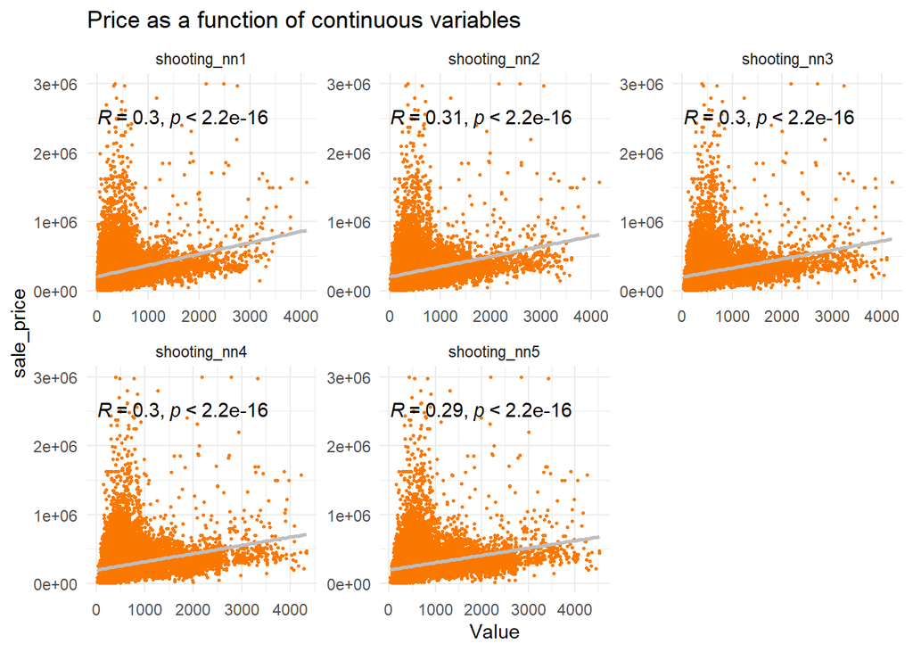

```r
baseline %>%
  st_drop_geometry() %>%
  dplyr::select(sale_price, starts_with("shooting_")) %>%
  gather(Variable, Value, -sale_price) %>%
   ggplot(aes(Value, sale_price)) +
     geom_point(size = .5, colour = "#FA7800") +
  stat_cor(label.y = 2500000) +
  geom_smooth(method = "lm", se=F, colour = "grey") +
     facet_wrap(~Variable, ncol = 3, scales = "free") +
     labs(title = "Price as a function of continuous variables") +
     theme_minimal()
```

The correlation matrix reveals a correlation between variables. Each cell in the matrix represents the correlation between two variables.

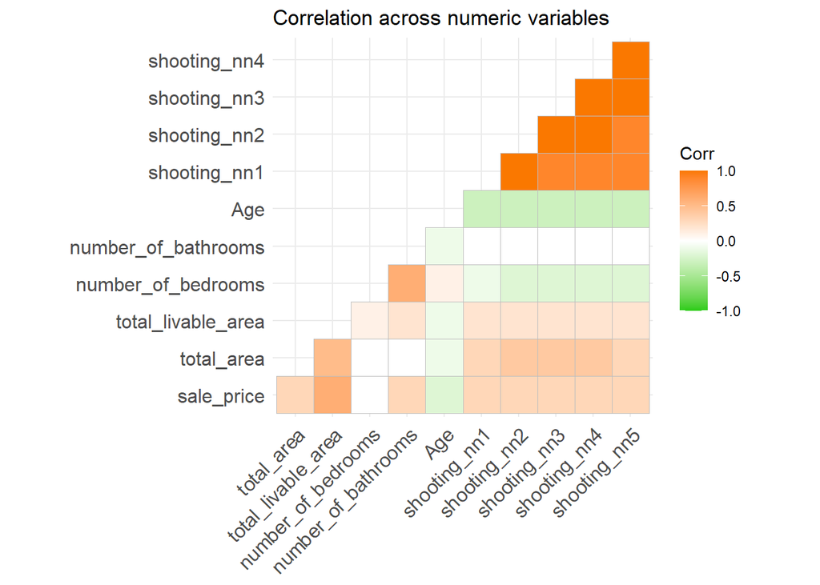

```r
vars <- select_if(st_drop_geometry(varibles), is.numeric) %>% na.omit()


ggcorrplot(
  round(cor(vars), 1),
  p.mat = cor_pmat(vars),
  colors = c("#25CB10", "white", "#FA7800"),
  type="lower",
  insig = "blank") +
    labs(title = "Correlation across numeric variables")
```

## Variables Map

This section develops variables maps show the value distribution of variables.

First, it develops three independent variable for the `age` (a feature crated from year_build), `total_area` , and `shooting.Buffer`. Then, building dependent variable map visualize the `sale_price` value distribution.

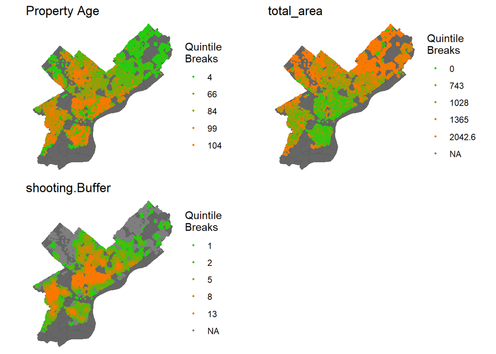

```r
q1 <-ggplot() +
  geom_sf(data = philly_tract, fill = "grey40") +
  geom_sf(data = baseline, aes(colour = q5(Age)),
          show.legend = "point", size = .75) +
  scale_colour_manual(values = palette5,
                   labels=qBr(baseline,"Age"),
                   name="Quintile\nBreaks") +
  labs(title="Property Age") +
  theme_void()

q2 <- ggplot() +
  geom_sf(data = philly_tract, fill = "grey40") +
  geom_sf(data = baseline, aes(colour = q5(total_area)),
          show.legend = "point", size = .75) +
  scale_colour_manual(values = palette5,
                   labels=qBr(baseline,"total_area"),
                   name="Quintile\nBreaks") +
  labs(title="total_area") +
  theme_void()

q3 <- ggplot() +
  geom_sf(data = philly_tract, fill = "grey40") +
  geom_sf(data = baseline, aes(colour = q5(shooting.Buffer)),
          show.legend = "point", size = .75) +
  scale_colour_manual(values = palette5,
                   labels=qBr(baseline,"shooting.Buffer"),
                   name="Quintile\nBreaks") +
  labs(title="shooting.Buffer") +
  theme_void()

combined_plot <- grid.arrange(q1, q2, q3,
                              ncol = 2)
```

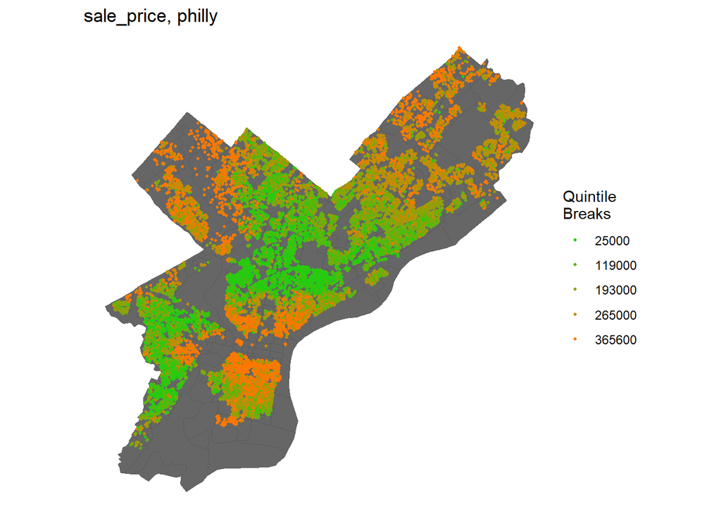

```r
ggplot() +
  geom_sf(data = philly_tract, fill = "grey40") +
  geom_sf(data = baseline, aes(colour = q5(sale_price)),
          show.legend = "point", size = .75) +
  scale_colour_manual(values = palette5,
                   labels=qBr(baseline,"sale_price"),
                   name="Quintile\nBreaks") +
  labs(title="sale_price, philly") +
  theme_void()
```

## Interesting Maps

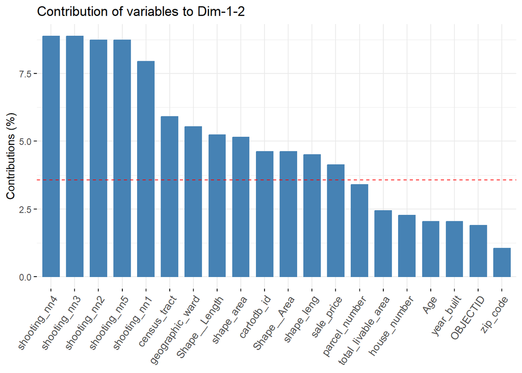

```r
baseline_numeric <- baseline %>%
  st_drop_geometry() %>%
  dplyr::select_if(is.numeric)

baseline_numeric <- baseline_numeric %>%
  select_if(~ var(.) != 0)

baseline_pca <- prcomp(baseline_numeric, center = TRUE, scale. = TRUE)

fviz_contrib(baseline_pca, choice = "var", axes = 1:2, top = 20) +
  theme(axis.text.x = element_text(size = 10, angle = 55))
```

The PCA results show that crime-related variables, especially proximity to shootings, and spatial context (census tracts and wards) are the most influential factors in explaining data variance. In comparison, property-specific characteristics like total livable area and sale price play a secondary role in shaping the underlying patterns.

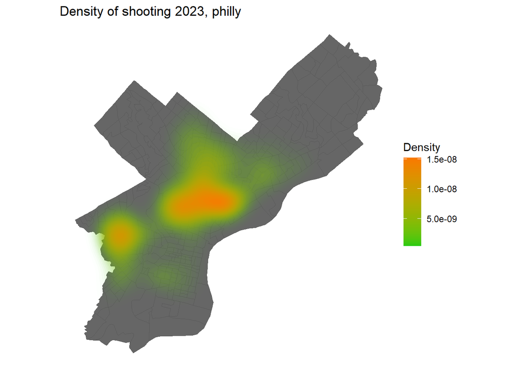

```r
ggplot() +
  geom_sf(data = philly_tract, fill = "grey40") +
  stat_density2d(data = data.frame(st_coordinates(shooting.23)),
                 aes(X, Y, fill = ..level.., alpha = ..level..),
                 size = 0.01, bins = 40, geom = 'polygon') +
  scale_fill_gradient(low = "#25CB10", high = "#FA7800", name = "Density") +
  scale_alpha(range = c(0.00, 0.35), guide = "none") +
  labs(title = "Density of shooting 2023, philly") +
  theme_void()
```

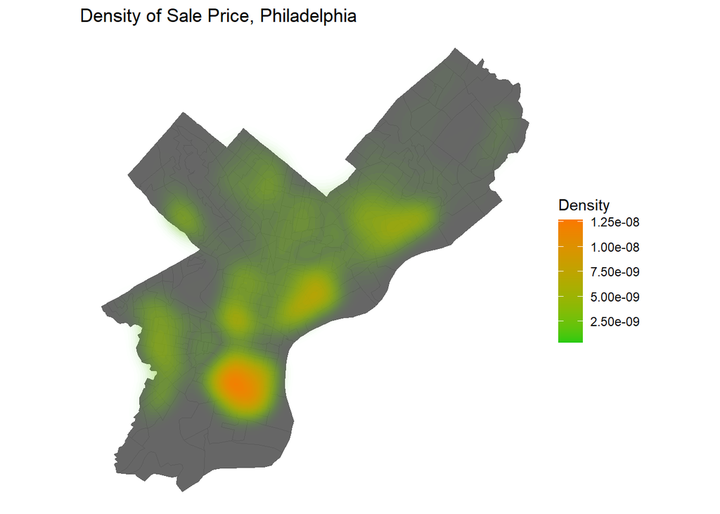

```r
# First, convert the baseline dataset with sale_price into coordinates
baseline_coords <- data.frame(st_coordinates(st_centroid(baseline)),
                              sale_price = baseline$sale_price)

# Plot the density map of sale_price
ggplot() +
  geom_sf(data = philly_tract, fill = "grey40") +
  stat_density2d(data = baseline_coords,
                 aes(X, Y, fill = ..level.., alpha = ..level..),
                 size = 0.01, bins = 40, geom = 'polygon') +
  scale_fill_gradient(low = "#25CB10", high = "#FA7800", name = "Density") +
  scale_alpha(range = c(0.00, 0.35), guide = "none") +
  labs(title = "Density of Sale Price, Philadelphia") +
  theme_void()
```

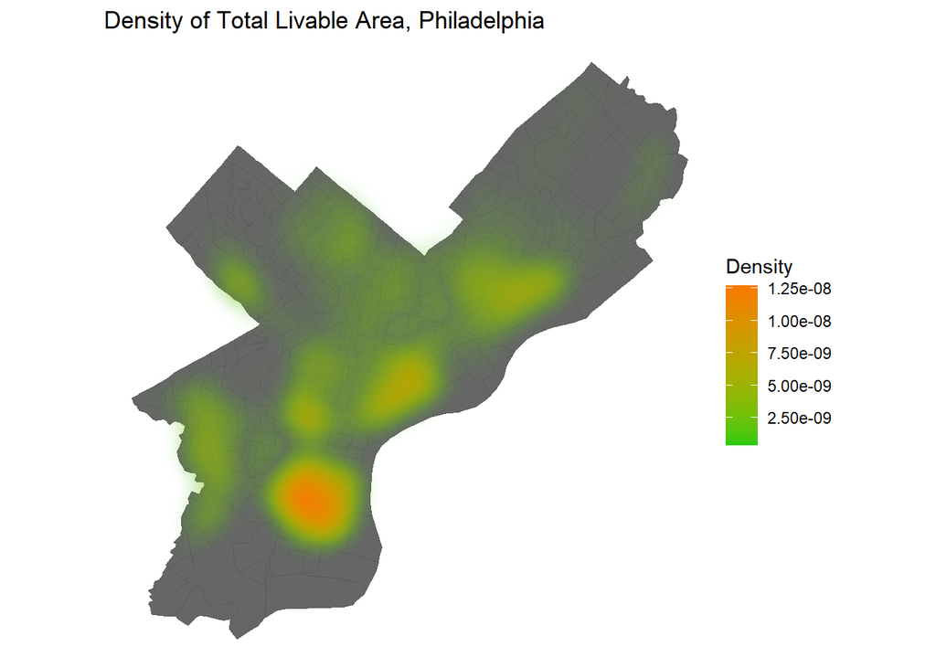

```r
# Convert the baseline dataset with total_livable_area into coordinates
baseline_livable_coords <- data.frame(st_coordinates(st_centroid(baseline)),
                                      total_livable_area = baseline$total_livable_area)

# Plot the density map of total_livable_area
ggplot() +
  geom_sf(data = philly_tract, fill = "grey40") +
  stat_density2d(data = baseline_livable_coords,
                 aes(X, Y, fill = ..level.., alpha = ..level..),
                 size = 0.01, bins = 40, geom = 'polygon') +
  scale_fill_gradient(low = "#25CB10", high = "#FA7800", name = "Density") +
  scale_alpha(range = c(0.00, 0.35), guide = "none") +
  labs(title = "Density of Total Livable Area, Philadelphia") +
  theme_void()
```

# Methodology

In the methodology, we develop some regression models to observe the sale_price. Then comparing those regression models finds a good variable to explain the `sale_price`. To address the Henomic model, we select those variables to explain the `sale_price`, including `total_area`, `total_livable_area`, `Age`, `number_of_bedrooms`,`shooting_Buffer`,among others.

The methodology for predicting sale prices is examined by the following steps:

**Data spliting:** Split data into “training” and “testing” sets that aim to assess model accuracy and generalizability. Then,`reg.training` employs a combination of variables to describe housing characteristics.

**Error metrics:** Various error metrics measure of error are attributed to each sale, some basic summary statistics describe goodness of fit.

**Cross-validation:** We implement cross-validation to evaluate the goodness of fit more reliably. This involves specifying the number of k-fold partitions, which in this case is set to 100. This ensures that the goodness of fit results are robust and can be generalized beyond the training data.

**Spatial lag analysis:** Incorporating spatial lag accounts for the influence of nearby observations on each other, displaying the relationship between the prediction error for a given house, and that of the neighboring house.

**Moran’s I:** Calculate Moran’s I access the spatial autocorrelation of `sale_prices.error`.This statistic aims to determine whether high or low `sale_price.error` cluster spatially.

**District regression:** We build district-level regression models to investigate housing prices within specific Districts in Philadelphia. By comparing the error metrics from district regression with those from the overall training set (reg.training), identifying any variations in predictive accuracy.

Through this comprehensive methodology, we aim to employ regression models, providing valuable insights into the factors affecting housing price prediction in Philadelphia.

# Result

## Split Data into Train & Test Set

To help Zillow build a predictive model for Philadelphia home prices, we started by cleaning and preparing the dataset to ensure reliability and consistency. The dataset was split into a 60% training set and a 40% test set, maintaining similar feature distributions between them. The training set was used to build the model, while the test set allowed us to validate its performance.

```r
training <- baseline %>%
  mutate(
    shooting.Buffer = case_when(
      is.na(shooting.Buffer) ~ 0,  # Replace NA in column A with 0
      TRUE ~ shooting.Buffer       # Keep existing values otherwise
    ),
    sale_price = case_when(
      is.na(sale_price) ~ 0,  # Replace NA in column A with 0
      TRUE ~ sale_price
    ),
    total_area = case_when(
      is.na(total_area) ~ 0,  # Replace NA in column A with 0
      TRUE ~ total_area
    ))
```

```r
set.seed(825)
inTrain <- createDataPartition( y =
                                  paste(
                                         training$quality,
                                          training$Garage,
                                          training$cen_air,
                                          training$NAME
                                        ),
                                p = .60, list = FALSE)

data.training <- baseline[inTrain,]
data.test <- baseline[-inTrain,]

data.test <- data.test %>%
  mutate(
    shooting.Buffer = case_when(
      is.na(shooting.Buffer) ~ 0,  # Replace NA in column A with 0
      TRUE ~ shooting.Buffer       # Keep existing values otherwise
    ),
    sale_price = case_when(
      is.na(sale_price) ~ 0,  # Replace NA in column A with 0
      TRUE ~ sale_price
    ),
    total_area = case_when(
      is.na(total_area) ~ 0,  # Replace NA in column A with 0
      TRUE ~ total_area
    )
    )
```

### Reg.training

Training Model Summary Statistics The Ordinary Least Squares (OLS) regression results show that features such as livable area and central air conditioning are positively correlated with home prices, suggesting a preference among buyers for modern, well-equipped homes. Conversely, proximity to crime incidents, represented by the shooting.Buffer variable, negatively impacts home prices, underscoring the role of neighborhood safety in purchasing decisions. The model achieved an Adjusted R² of 0.5231, indicating that around 52.3% of the variation in home prices can be explained by these variables. This provides a moderate understanding of the factors influencing Philadelphia’s housing market. To ensure consistency and validate the model’s generalizability, the same data cleaning steps were applied to the test set.

```r
reg.training <- lm(sale_price ~ .,
                   data = st_drop_geometry(data.training) %>%
                                    dplyr::select(sale_price, total_area,
                                                  building,
                                                  quality,
                                                  total_livable_area,
                                                  number_of_bedrooms,
                                                  number_of_bathrooms,
                                                  cen_air,Garage,
                                                  Age, shooting.Buffer))



reg.training_summary <- tidy(reg.training) %>%
  select(term, estimate, std.error, statistic, p.value) %>%
  rename(
    Term = term,
    Estimate = estimate,
    "Standard Error" = std.error,
    "T-Statistic" = statistic,
    "P-Value" = p.value
  )

pander(reg.training_summary, caption = "Regression training Model Summary")
```

Regression training Model Summary

| Term | Estimate | Standard Error | T-Statistic | P-Value |
| --- | --- | --- | --- | --- |
| (Intercept) | 17364 | 14448 | 1.202 | 0.2295 |
| total_area | -21.63 | 1.249 | -17.32 | 2.266e-66 |
| buildingRow | -23220 | 6412 | -3.621 | 0.0002942 |
| buildingTWIN | -45242 | 7168 | -6.311 | 2.865e-10 |
| qualityGood | 99255 | 7536 | 13.17 | 2.456e-39 |
| total_livable_area | 214.8 | 3.359 | 63.95 | 0 |
| number_of_bedrooms | -30387 | 1632 | -18.62 | 2.924e-76 |
| number_of_bathrooms | 62676 | 3128 | 20.04 | 7.925e-88 |
| cen_airY | 117010 | 3483 | 33.6 | 2.497e-236 |
| GarageY | -7620 | 11509 | -0.6621 | 0.5079 |
| Age | 464.2 | 52.3 | 8.876 | 7.957e-19 |
| shooting.Buffer | -5752 | 155.3 | -37.05 | 3.451e-284 |

```r
# Additional summary statistics
r_squared <- summary(reg.training)$r.squared
adj_r_squared <- summary(reg.training)$adj.r.squared
f_statistic <- summary(reg.training)$fstatistic[1]
p_value <- pf(f_statistic, df1 = summary(reg.training)$fstatistic[2],
              df2 = summary(reg.training)$fstatistic[3], lower.tail = FALSE)

# Display as a single table or add to model_summary table if preferred
additional_stats <- data.frame(
  Metric = c("R-squared", "Adjusted R-squared", "F-statistic", "Model P-Value"),
  Value = c(r_squared, adj_r_squared, f_statistic, p_value)
)

pander(additional_stats, caption = "Training Model Summary Statistics", style = "grid")
```

Training Model Summary Statistics

```
  Metric
```

Value

```
R-squared
```

0.5236

Adjusted R-squared

0.5231

F-statistic

1172

Model P-Value

0

### Accuracy - Mean Absolute Error

Based on the updated results, the accuracy of our baseline regression model in predicting home sale prices was assessed using the Mean Absolute Error (MAE) and Mean Absolute Percentage Error (MAPE). The model’s MAE is approximately $97,875.17, indicating that, on average, the predicted sale prices deviate from actual prices by around $97,875. This level of absolute error suggests that there is still substantial room for improvement in the model to align more closely with market prices. Additionally, the MAPE is 52.58%, which implies that, on average, the model’s predictions are off by about 52.6% from the actual sale prices. This high percentage error indicates the model’s limitations, particularly in capturing price variability across different price ranges, and underscores the need for refinement to improve its predictive precision.

```r
data.test<-
  data.test  %>%
  mutate(Regression = "Baseline Regression",
         sale_price.Predict = predict(reg.training, data.test),
         sale_price.Error = sale_price.Predict - sale_price,
         sale_price.AbsError = abs(sale_price.Predict - sale_price),
         sale_price.APE = (abs(sale_price.Predict - sale_price)) / sale_price.Predict)


mean(data.test$sale_price) # mean of the sale price
```

```
## [1] 273174.4
```

```r
data.test %>%
    filter(!is.na(sale_price), !is.na(sale_price.Predict)) %>%
  st_drop_geometry() %>%
  summarise(MAE = mean(sale_price.AbsError),
            MAPE = mean(sale_price.APE)*100) %>%
  kbl(col.name=c('Mean Absolute Error','Mean Absolute Percentage Error')) %>%
  kable_styling( bootstrap_options = c("striped", "hover", "condensed"))
```

| Mean Absolute Error | Mean Absolute Percentage Error |
| --- | --- |
| 97875.17 | 52.57657 |

### Cross Validation & Return to Goodness of Fit

Based on the updated cross-validation results, we used 100-fold cross-validation to evaluate the model’s stability ability of generalizing.

```r
fitControl <- trainControl(method = "cv", number = 100)
#a parameter called fitControl is set to specify the number of k-fold partitions - in this case 100.
set.seed(825)#ensures reproducible folds


reg.cv <-
  train(sale_price ~ .,
        data = st_drop_geometry(baseline) %>%
          dplyr::select(sale_price, total_area,
                                                  building,
                                                  quality,
                                                  total_livable_area,
                                                  number_of_bedrooms,
                                                  number_of_bathrooms,
                                                  cen_air,
                                                  Age,
                                                  shooting.Buffer),
method = "lm", trControl = fitControl, na.action = na.pass)

reg.cv
```

```
## Linear Regression
##
## 23740 samples
##     9 predictor
##
## No pre-processing
## Resampling: Cross-Validated (100 fold)
## Summary of sample sizes: 23503, 23501, 23504, 23503, 23503, 23502, ...
## Resampling results:
##
##   RMSE      Rsquared   MAE
##   143426.2  0.5475396  91116.18
##
## Tuning parameter 'intercept' was held constant at a value of TRUE
```

```r
reg.cv$resample[1:5,] %>%
  pander()
```

| RMSE | Rsquared | MAE | Resample |
| --- | --- | --- | --- |
| 171954 | 0.4281 | 104578 | Fold001 |
| 120569 | 0.6176 | 83146 | Fold002 |
| 103391 | 0.5814 | 77777 | Fold003 |
| 128445 | 0.5862 | 86087 | Fold004 |
| 131216 | 0.5224 | 84955 | Fold005 |

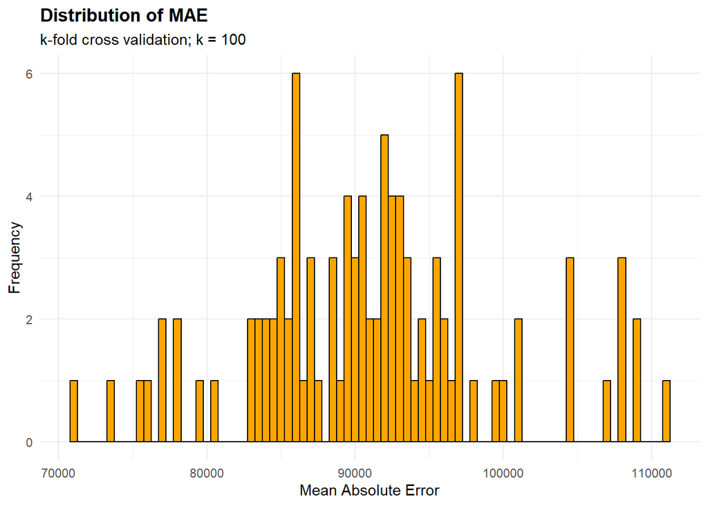

```r
# `resample` holds individual fold results
cv_results <- reg.cv$resample$MAE

# Plot histogram of MAE values
ggplot(data.frame(MAE = cv_results), aes(x = MAE)) +
  geom_histogram(binwidth = 500, fill = "orange", color = "black") +
  labs(title = "Distribution of MAE",
       subtitle = "k-fold cross validation; k = 100",
       x = "Mean Absolute Error",
       y = "Frequency") +
  theme_minimal() +
  theme(plot.title = element_text(face = "bold"))
```

### Do Prices & Errors cluster? - The Spatial Lag

We can use this technique to look at the “spatial lag” of nearby prices.

```r
#set.seed(825)#ensures reproducible folds

coords <- st_coordinates(baseline)

neighborList <- knn2nb(knearneigh(coords, 5))

spatialWeights <- nb2listw(neighborList, style="W")

baseline$lagPrice <- lag.listw(spatialWeights, baseline$sale_price)

data.test <- data.test %>%
  filter(is.finite(sale_price.Error))

#data.test
coords.test <-  st_coordinates(data.test)

neighborList.test <- knn2nb(knearneigh(coords.test, 5))

spatialWeights.test <- nb2listw(neighborList.test, style="W")
```

The spatial lag analysis reveals a positive correlation between a property’s prediction error and the average error of nearby properties. This clustering indicates that underestimations are likely influenced by neighborhood factors, highlighting the need to consider local spatial dependencies to enhance model accuracy.

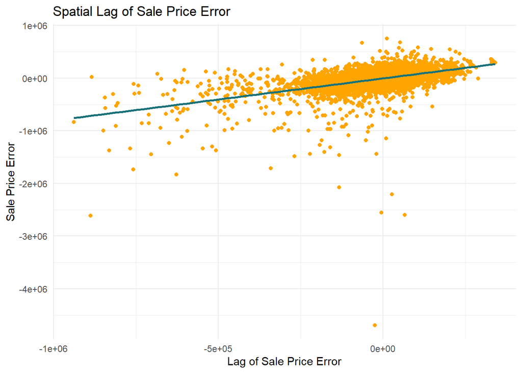

```r
data.test %>%
  mutate(lagPriceError = lag.listw(spatialWeights.test, sale_price.Error)) %>%
  ggplot()+
  geom_point(aes(x =lagPriceError, y =sale_price.Error), color = "orange") +
  stat_smooth(aes(lagPriceError, sale_price.Error),
             method = "lm", se = FALSE, size = 1, colour="#197278") +
  labs(title = "Spatial Lag of Sale Price Error",
       x = "Lag of Sale Price Error",
       y = "Sale Price Error") +
  theme_minimal()
```

The Pearson correlation coefficient of 0.51 (p < 0.001) confirms spatial clustering of prediction errors, indicating that neighborhood-specific factors impact model performance. This result suggests that incorporating more localized spatial features could help reduce clustering of errors and enhance predictive accuracy.

```r
pearsons_test <-
  data.test %>%
  mutate(lagPriceError = lag.listw(spatialWeights.test, sale_price.Error))

cor.test(pearsons_test$lagPriceError,
         pearsons_test$sale_price.Error,
         method = "pearson")
```

```
##
##  Pearson's product-moment correlation
##
## data:  pearsons_test$lagPriceError and pearsons_test$sale_price.Error
## t = 57.487, df = 9393, p-value < 2.2e-16
## alternative hypothesis: true correlation is not equal to 0
## 95 percent confidence interval:
##  0.4950443 0.5249644
## sample estimates:
##       cor
## 0.5101587
```

### Do Model Errors Cluster? - Moran’s I

The Moran’s I test results indicate significant spatial clustering in the model’s prediction errors, as the observed Moran’s I value (shown by the orange line) is considerably higher than expected under random distribution. This suggests strong spatial autocorrelation, implying that the model’s errors tend to cluster by location.

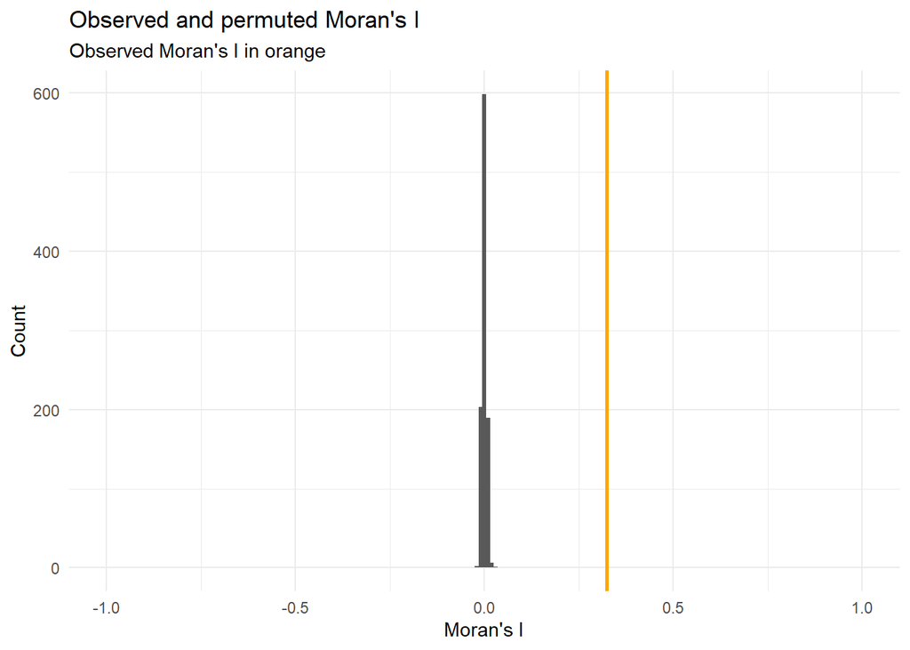

```r
moranTest <- moran.mc(data.test$sale_price.Error,
                      spatialWeights.test, nsim = 999)

ggplot(as.data.frame(moranTest$res[c(1:999)]), aes(moranTest$res[c(1:999)])) +
  geom_histogram(binwidth = 0.01) +
  geom_vline(aes(xintercept = moranTest$statistic), colour = "orange",size=1) +
  scale_x_continuous(limits = c(-1, 1)) +
  labs(title="Observed and permuted Moran's I",
       subtitle= "Observed Moran's I in orange",
       x="Moran's I",
       y="Count") +
  theme_minimal()
```

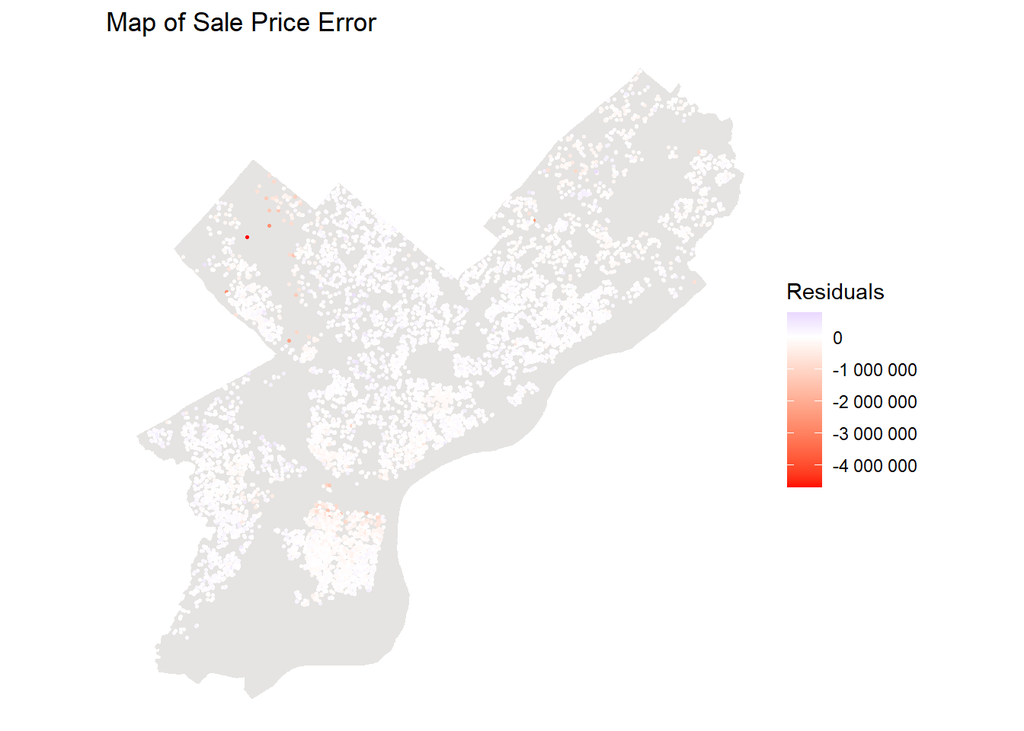

```r
ggplot() +
  geom_sf(data = phiily_hoods, fill = '#E5E4E2', color = 'transparent') +
  geom_sf(data = data.test, aes(colour = sale_price.Error), size = 0.5) +
  scale_colour_gradient2(low = "red",  high = "blue",
                         midpoint = 0, name = "Residuals",
                         labels = label_number(scale = 1, accuracy = 1)) +  # Format legend labels
  labs(title = "Map of Sale Price Error") +
  theme_void()  # Using a simple void theme
```

## Neighborhood/district regression

### Neighborhood

```r
reg.nhood <- lm(sale_price ~ ., data = as.data.frame(data.training) %>%
                                 dplyr::select(name, sale_price,
                                               total_area, building,
                                                  quality,
                                                  total_livable_area,
                                                  number_of_bedrooms,
                                                  number_of_bathrooms,
                                                  cen_air,Garage,
                                                  Age, shooting.Buffer))


reg.nhood_summary <- tidy(reg.nhood) %>%
  select(term, estimate, std.error,  p.value) %>% #statistic,
  rename(
    Term = term,
    Estimate = estimate,
    "Standard Error" = std.error, #"T-Statistic" = statistic,
    "P-Value" = p.value
  )

#pander(reg.nhood_summary, caption = "Dsitricted Regression Model Coefficients Summary")



r_squared_hood <- summary(reg.nhood)$r.squared
adj_r_squared_hood <- summary(reg.nhood)$adj.r.squared
f_statistic_hood <- summary(reg.nhood)$fstatistic[1]
p_value_hood <- pf(f_statistic, df1 = summary(reg.nhood)$fstatistic[2],
              df2 = summary(reg.nhood)$fstatistic[3], lower.tail = FALSE)

# Display as a single table or add to model_summary table if preferred
additional_stats_hood <- data.frame(
  Metric = c("R-squared", "Adjusted R-squared", "F-statistic", "Model P-Value"),
  Value = c(r_squared_hood, adj_r_squared_hood, f_statistic_hood, p_value_hood)
)

pander(additional_stats_hood, caption = "Neghborhood Model Summary Statistics", style = "simple")
```

Neghborhood Model Summary Statistics

| Metric | Value |
| --- | --- |
| R-squared | 0.7154 |
| Adjusted R-squared | 0.7118 |
| F-statistic | 199.6 |
| Model P-Value | 0 |

### District

```r
reg.ndist <- lm(sale_price ~ ., data = as.data.frame(data.training) %>%
                                 dplyr::select(DIST_NAME,
                                               sale_price,
                                               total_area, building,
                                                  quality,
                                                  total_livable_area,
                                                  number_of_bedrooms,
                                                  number_of_bathrooms,
                                                  cen_air,Garage,
                                                  Age, shooting.Buffer))


reg.ndist_summary <- tidy(reg.ndist) %>%
  select(term, estimate, std.error,  p.value) %>% #statistic,
  rename(
    Term = term,
    Estimate = estimate,
    "Standard Error" = std.error, #"T-Statistic" = statistic,
    "P-Value" = p.value
  )

pander(reg.ndist_summary, caption = "Dsitrict Regression Model Coefficients Summary")
```

Dsitrict Regression Model Coefficients Summary

| Term | Estimate | Standard Error | P-Value |
| --- | --- | --- | --- |
| (Intercept) | 214962 | 13066 | 3.812e-60 |
| DIST_NAMECentral Northeast | -259158 | 8883 | 1.038e-180 |
| DIST_NAMELower Far Northeast | -264351 | 8828 | 6.55e-190 |
| DIST_NAMELower North | -291730 | 6682 | 0 |
| DIST_NAMELower Northeast | -328256 | 6569 | 0 |
| DIST_NAMELower Northwest | -230998 | 8289 | 1.592e-165 |
| DIST_NAMELower South | -223800 | 41708 | 8.209e-08 |
| DIST_NAMELower Southwest | -345932 | 8324 | 0 |
| DIST_NAMENorth | -338137 | 6596 | 0 |
| DIST_NAMENorth Delaware | -306021 | 6387 | 0 |
| DIST_NAMERiver Wards | -255120 | 6117 | 0 |
| DIST_NAMESouth | -220646 | 5373 | 0 |
| DIST_NAMEUniversity Southwest | -308537 | 7840 | 3.067e-318 |
| DIST_NAMEUpper Far Northeast | -220891 | 15652 | 7.407e-45 |
| DIST_NAMEUpper North | -342744 | 6263 | 0 |
| DIST_NAMEUpper Northwest | -344865 | 7582 | 0 |
| DIST_NAMEWest | -317448 | 6645 | 0 |
| DIST_NAMEWest Park | -352847 | 10517 | 1.093e-235 |
| total_area | 0.8781 | 1.181 | 0.457 |
| buildingRow | 64094 | 5776 | 1.82e-28 |
| buildingTWIN | 56598 | 6450 | 1.944e-18 |
| qualityGood | 41235 | 6588 | 4.018e-10 |
| total_livable_area | 184.5 | 3.001 | 0 |
| number_of_bedrooms | -11306 | 1439 | 4.222e-15 |
| number_of_bathrooms | 47559 | 2716 | 8.46e-68 |
| cen_airY | 59817 | 3135 | 5.815e-80 |
| GarageY | -13601 | 9864 | 0.168 |
| Age | 96.24 | 48.76 | 0.04846 |
| shooting.Buffer | -3737 | 164.3 | 3.956e-112 |

```r
# Additional summary statistics
r_squared_dist <- summary(reg.ndist)$r.squared
adj_r_squared_dist <- summary(reg.ndist)$adj.r.squared
f_statistic_dist <- summary(reg.ndist)$fstatistic[1]
p_value_dist <- pf(f_statistic, df1 = summary(reg.ndist)$fstatistic[2],
              df2 = summary(reg.ndist)$fstatistic[3], lower.tail = FALSE)

# Display as a single table or add to model_summary table if preferred
additional_stats_dist <- data.frame(
  Metric = c("R-squared", "Adjusted R-squared", "F-statistic", "Model P-Value"),
  Value = c(r_squared_dist, adj_r_squared_dist, f_statistic_dist, p_value_dist)
)

pander(additional_stats_dist, caption = "District Model Summary Statistics", style = "simple")
```

District Model Summary Statistics

| Metric | Value |
| --- | --- |
| R-squared | 0.6513 |
| Adjusted R-squared | 0.6505 |
| F-statistic | 781.1 |
| Model P-Value | 0 |

```r
data.test.ndist <- data.test %>%
  mutate(Regression = "district Effects",
         sale_price.Predict = predict(reg.ndist, data.test),
         sale_price.Error = sale_price.Predict- sale_price,
         sale_price.AbsError = abs(sale_price.Predict- sale_price),
         sale_price.APE = ifelse(sale_price.Predict != 0,
                                  abs(sale_price.Predict - sale_price) / sale_price.Predict, NA))
```

## Comparing

Mean Absolute Error and Absolute Percentage Error by Regression The comparison between the Baseline Regression and the District Effects model highlights the advantages of incorporating district-level information in predicting home sale prices. The Baseline Regression model has a Mean Absolute Error (MAE) of 97,875 and a Mean Absolute Percentage Error (MAPE) of 0.5258, indicating moderate prediction accuracy. By contrast, the District Effects model achieves a lower MAE of 79,475 and a reduced MAPE of 0.32, suggesting an overall improvement in prediction accuracy.

```r
bothRegressions <-
  rbind(
    dplyr::select(data.test, starts_with("sale_price"), Regression, DIST_NAME) %>%
      mutate(lagPriceError = lag.listw(spatialWeights.test, sale_price.Error)),
    dplyr::select(data.test.ndist, starts_with("sale_price"), Regression, DIST_NAME) %>%
      mutate(lagPriceError = lag.listw(spatialWeights.test, sale_price.Error)))


st_drop_geometry(bothRegressions) %>%
  gather(Variable, Value, -Regression, -DIST_NAME) %>%
  filter(Variable == "sale_price.AbsError" | Variable == "sale_price.APE") %>%
  group_by(Regression, Variable) %>%
    summarize(meanValue = mean(Value, na.rm = T)) %>%
    spread(Variable, meanValue) %>%
    pander(caption = "Mean Absolute Error and Absolute Percentage Error by Regression")
```

Mean Absolute Error and Absolute Percentage Error by Regression

| Regression | sale_price.AbsError | sale_price.APE |
| --- | --- | --- |
| Baseline Regression | 97875 | 0.5258 |
| district Effects | 79475 | 0.32 |

The plot shows that the District Effects model (right) aligns more closely with the perfect prediction line (orange) compared to the Baseline Regression model (left), especially at higher price ranges. This indicates that adding district-specific information improves the model’s ability to capture local variations in property values, reducing prediction errors.

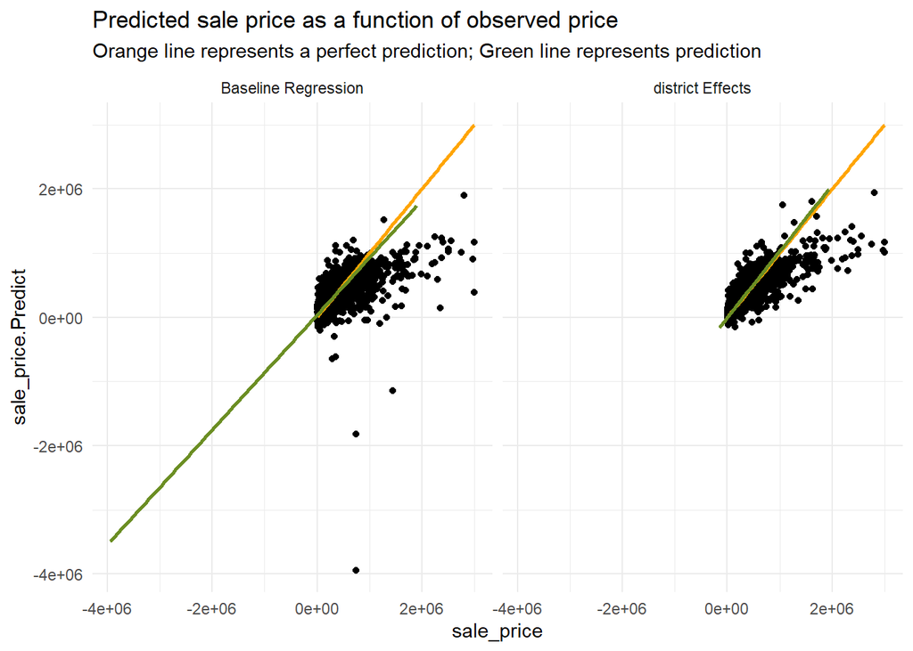

```r
bothRegressions %>%
  dplyr::select(sale_price.Predict, sale_price, Regression) %>%
    ggplot(aes(sale_price, sale_price.Predict)) +
  geom_point() +
  stat_smooth(aes(sale_price, sale_price),
             method = "lm", se = FALSE, size = 1, colour="orange") +
  stat_smooth(aes(sale_price.Predict, sale_price),
              method = "lm", se = FALSE, size = 1, colour="olivedrab") +
  facet_wrap(~Regression) +
  labs(title="Predicted sale price as a function of observed price",
       subtitle="Orange line represents a perfect prediction; Green line represents prediction") +
  theme_minimal()
```

### Spatial Evaluation of Errors

The left map, representing the Baseline Regression, shows areas with higher MAPE in orange, indicating less accurate predictions, particularly in certain central districts. The right map for the District Effects model shows improved accuracy, with most areas shaded green, indicating lower MAPE and better alignment between predicted and actual values.This comparison suggests that incorporating district-specific factors significantly enhances model accuracy across Philadelphia, especially in regions where the baseline model previously underperformed.

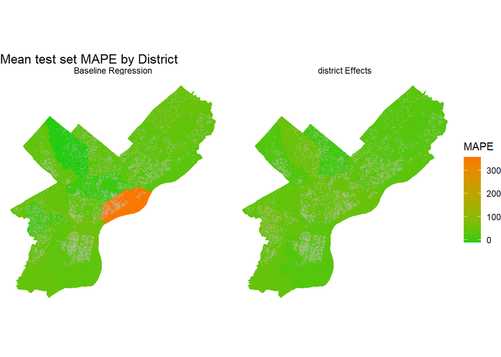

```r
st_drop_geometry(bothRegressions) %>%
  group_by(Regression, DIST_NAME) %>%
  summarize(mean.MAPE = mean(sale_price.APE, na.rm = T)) %>%
  ungroup() %>%
  left_join(dist, by = c("DIST_NAME" = "DIST_NAME")) %>%
    st_sf() %>%
    ggplot() +
      geom_sf(aes(fill = 100*mean.MAPE), color = "transparent") +
      geom_sf(data = bothRegressions, colour = "grey", size = .1, alpha = 0.3) +
      facet_wrap(~Regression) +
      scale_fill_gradient(low = palette5[1], high = palette5[5],
                          name = "MAPE") +
      labs(title = "Mean test set MAPE by District") +
      theme_void()
```

MAPE generally shows a downward trend, stabilizes in the mid-price range, and then slightly increases in the highest price range. This suggests that the model performs better in neighborhoods with moderate prices, while prediction errors are higher in both lower and higher price ranges.

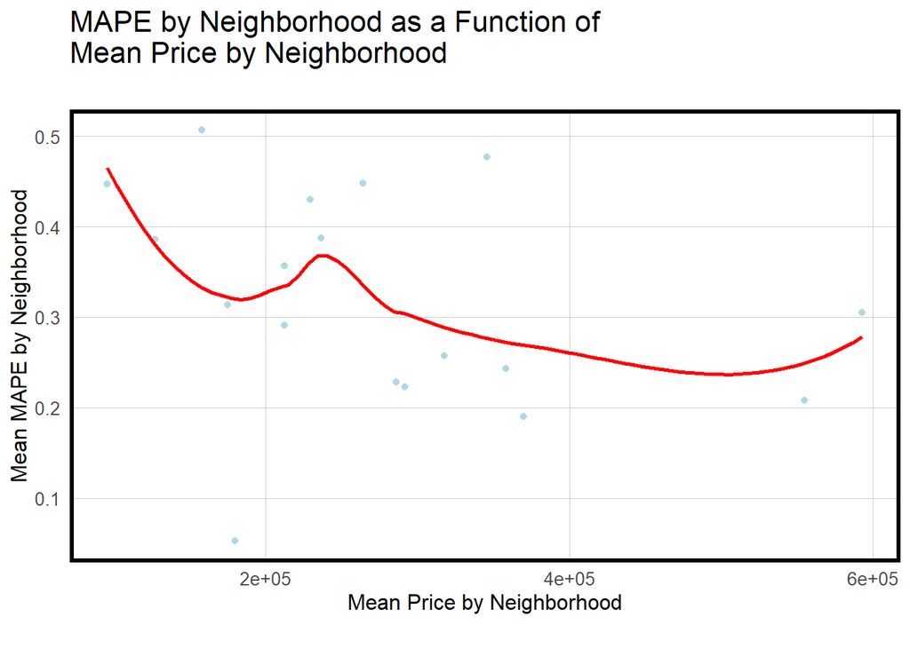

```r
ndist.df <- data.test.ndist %>%
  group_by(DIST_NAME) %>%
  summarise(meanMAPE = mean(sale_price.APE, na.rm = T),
            meanPrice = mean(sale_price, na.rm = T)) %>%   st_drop_geometry()

ggplot()+
  geom_point(data = ndist.df, aes(x = meanPrice, y = meanMAPE), color = "lightblue") +
  stat_smooth(data = ndist.df, aes(x = meanPrice, y = meanMAPE), method = "loess", se = FALSE, size = 1, colour="red") +
  labs(title = "MAPE by Neighborhood as a Function of\nMean Price by Neighborhood\n",
       caption = '') +
  xlab('Mean Price by Neighborhood') +
  ylab('Mean MAPE by Neighborhood') +
  plotTheme()
```

## “MODELLING” and “CHALLENGE” Map

This map visualizes the distribution of predicted values for the “Challenge” dataset across different areas in Philadelphia.

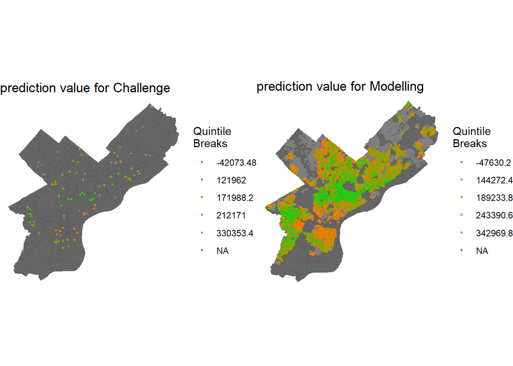

```r
cha <- ggplot() +
  geom_sf(data = philly_tract, fill = "grey40") +
  geom_sf(data = PricePrediction_challenge, aes(colour = q5(prediction)),
          show.legend = "point", size = .75) +
  scale_colour_manual(values = palette5,
                   labels=qBr(PricePrediction_challenge,"prediction"),
                   name="Quintile\nBreaks") +
  labs(title="prediction value for Challenge") +
  theme_void()

mod <- ggplot() +
  geom_sf(data = philly_tract, fill = "grey40") +
  geom_sf(data = PricePrediction_model, aes(colour = q5(prediction)),
          show.legend = "point", size = .75) +
  scale_colour_manual(values = palette5,
                   labels=qBr(PricePrediction_model,"prediction"),
                   name="Quintile\nBreaks") +
  labs(title="prediction value for Modelling") +
  theme_void()

combined_plot <- grid.arrange(cha, mod,
                              ncol = 2)
```

## Race and Income Context of Predictions

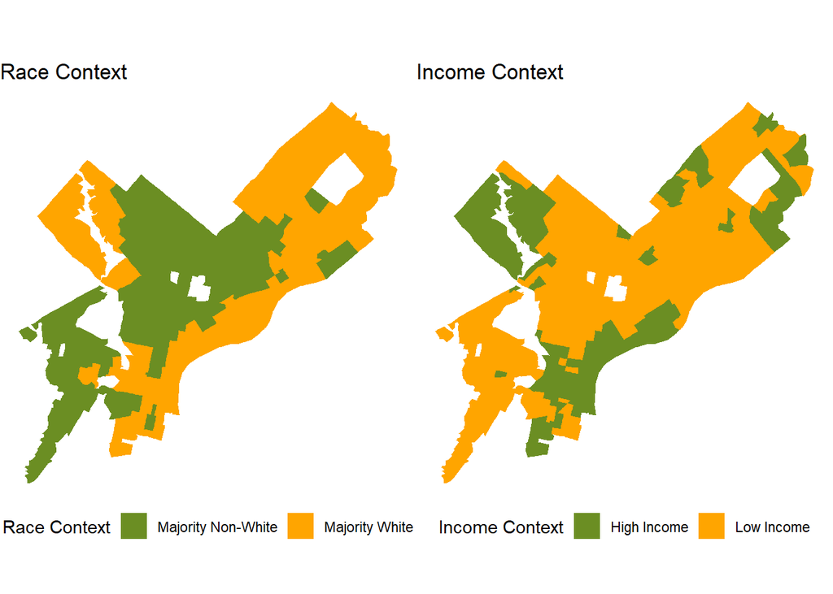

```r
grid.arrange(ncol = 2,
  ggplot() + geom_sf(data = na.omit(philly_tract), aes(fill = raceContext), color = "transparent") +
    scale_fill_manual(values = c("olivedrab", "orange"), name="Race Context") +
    labs(title = "Race Context") +
    theme_void() + theme(legend.position="bottom"),
  ggplot() + geom_sf(data = na.omit(philly_tract), aes(fill = incomeContext), color = "transparent") +
    scale_fill_manual(values = c("olivedrab", "orange"), name="Income Context") +
    labs(title = "Income Context") +
    theme_void() + theme(legend.position="bottom"))
```

Test set MAPE by neighborhood income context For high-income neighborhoods, both the baseline and district effects models perform relatively well, with MAPE values of 32.93 and 29.44, respectively. For low-income neighborhoods, the district effects model significantly improves accuracy, reducing MAPE from 61.23 (baseline) to 33.11. These results suggest that incorporating district effects not only improves overall prediction accuracy but also notably enhances the model’s performance in economically diverse neighborhoods.

```r
st_join(bothRegressions, philly_tract) %>%
  filter(!is.na(incomeContext)) %>%
  group_by(Regression, incomeContext) %>%
  summarize(mean.MAPE = 100*(mean(sale_price.APE, na.rm = T))) %>%
  st_drop_geometry() %>%
  spread(incomeContext, mean.MAPE) %>%
  pander(caption = "Test set MAPE by neighborhood income context")
```

Test set MAPE by neighborhood income context

| Regression | High Income | Low Income |
| --- | --- | --- |
| Baseline Regression | 32.93 | 61.23 |
| district Effects | 29.44 | 33.11 |

# Discussion

Interesting Variables: Key predictors include living area, central air conditioning, and proximity to crime. Larger living spaces and amenities, such as central air, increase home values, while proximity to crime lowers them, underscoring buyer preferences for safety. However, the relative importance of these variables appears to fluctuate across different neighborhoods and price ranges, indicating complex interaction effects that may not be fully captured by our linear model.

Model Generalizability: While the model performs well on the current dataset, its generalizability requires careful consideration based on multiple factors. First, the model’s heavy reliance on district-specific features may limit its applicability to other cities or regions with different neighborhood characteristics. Second, our cross-validation analysis reveals significant variations in performance across different subsamples (MAE ranging from 70,000 to 110,000), indicating potential challenges in generalizing to new data even within Philadelphia. Third, when tested across different demographic contexts, the model shows notably different error patterns: MAPE values of 29.44% for high-income neighborhoods versus 33.11% for low-income areas suggest systematic differences in prediction reliability across socioeconomic contexts. Additionally, temporal generalizability remains untested, as our model doesn’t account for potential changes in market dynamics over time.

Error Analysis: With an MAE of $97,875, the model has notable prediction errors, especially in extreme price ranges. This suggests that the model’s predictive power might not generalize well to luxury properties or very affordable housing segments. Our analysis of prediction errors reveals a systematic pattern: the model tends to underestimate prices in high-value districts and overestimate in lower-value areas, indicating a potential regression toward the mean effect that could limit its practical application across diverse market segments.

Spatial Variation: The Moran’s I test reveals significant spatial clustering of errors (p < 0.001), especially in areas with diverse demographics and high crime rates. The model performs better in middle- and high-income neighborhoods, while low-income, high-volatility areas present more significant challenges. This spatial heterogeneity in performance, combined with the observed error patterns in our cross-validation testing, suggests that the model’s reliability varies substantially across different socioeconomic contexts. The clustering of errors also indicates the presence of unobserved spatial factors that our current variable set may not adequately capture.

# Conclusion

**Recommendation**:  
We recommend this model as a reference tool for Zillow, particularly for predicting home prices in middle- and high-income neighborhoods. However, caution is advised when interpreting results for low-income areas, especially in city center regions, due to the model’s lower accuracy in these areas.

**Suggested Improvements**:

- **Optimize Feature Selection**:  
  Introduce additional economic and social variables, such as income levels and accessibility to services. Applying logarithmic or power transformations to key variables may improve the fit for linear regression models.
- **Use Advanced Modeling Techniques**:  
  Explore non-linear regression techniques, such as random forests, gradient boosting, or neural networks, to better capture complex non-linear relationships—particularly with larger datasets.
- **Increase Spatial Resolution**:  
  Currently, the model uses district-level data for spatial characteristics. Switching to neighborhood-level data could help capture more localized variations in house prices, adding granularity, which is especially beneficial in complex urban environments.
- **Consider Spatial Dependence**:  
  Incorporate spatial regression models or geographically weighted regression (GWR) to better account for spatial heterogeneity. This may reduce prediction errors across different regions.

With further optimization, this model could more effectively support Zillow’s pricing decisions, catering to a diverse range of market conditions.